# Analysis of Trajectories of Multiple Coin Tossing Experiment

Ryan Durfey

Saturday, October 04, 2014

### Introduction:

In this assignment, our aim is to understand “random walks” of a coin that is tossed 100,000 or 1,000,000 times.

### Data:

Instead of actually flipping a coin 100,000 times, we use the following R code to randomly generate these flips.

```r
set.seed(12345)
nFlips<-100000
Flips<-rbinom(nFlips,1,0.5)

# We can print a sample of our 100,000 flips
head(Flips,10)
```

```
##  [1] 1 1 1 1 0 0 0 1 1 1
```

### Experiment No. 1:

From the generated data, above, we can plot the trajectory of frequencies

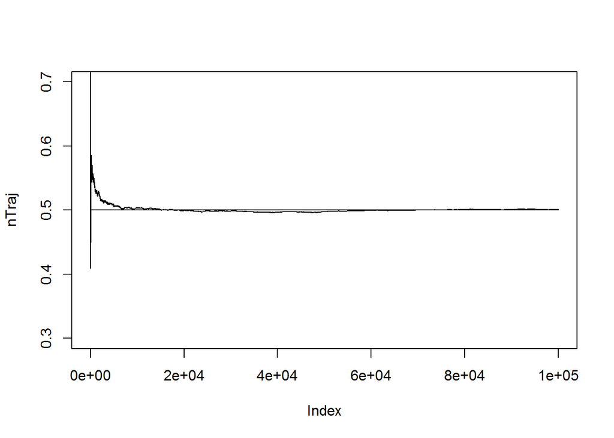

```r
Trajectory<-cumsum(Flips)
nTraj<-Trajectory/(1:nFlips)
plot(nTraj,ylim=c(.3,.7),type="l")
lines(c(0,nFlips),c(.5,.5))
```

In this initial graph, we see that the percentage of heads, which is represented on the y-axis, starts out deviating from 0.5 quite wildly, but then calms down and approaches 0.5 and then hovers closer and closer to it. We can interpret this this to mean that as the number of coin flips approaches infinity, the percentage of tails is 0.5 or 50%. However, it must be noted that with our finite number of coin flips in this experiment, it may not be exactly 0.5. Thus, in this experiement we could expect the trajectory to deviate from 0.5 only with a low number of flips, but otherwise approach and remain near 0.5 (even if not exactly 0.5).

We may also create a trajectory that goes up one step if the outcome is tails and down one step if the outcome is heads. For this we will use 1,000,000 flips. Our intuition may tell us that here, similar to the graph showing percentages of tails, that the trajectories will approach and hover around zero. However, that assumption is incorrect, as we can see in the graphs below.

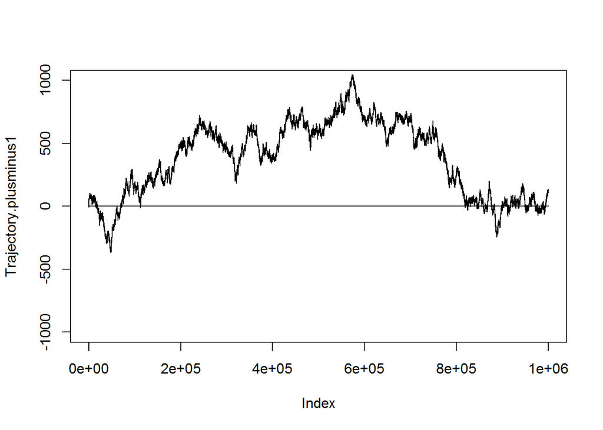

```r
set.seed(12345)  #We use the set.seed function to set the state of the random number generator. This aids in the reproducibility of experiment results.
nFlips<-1000000
Flips.plusminus1<-(rbinom(nFlips,1,0.5)-.5)*2
Trajectory.plusminus1<-cumsum(Flips.plusminus1)
plot(Trajectory.plusminus1,ylim=c(-1000,1000),type="l")
lines(c(0,nFlips),c(0,0))
```

We can also run this experiment again, using a different set.seed number, which should give us slightly different results as the random number generator works slightly differently to create our set of flips.

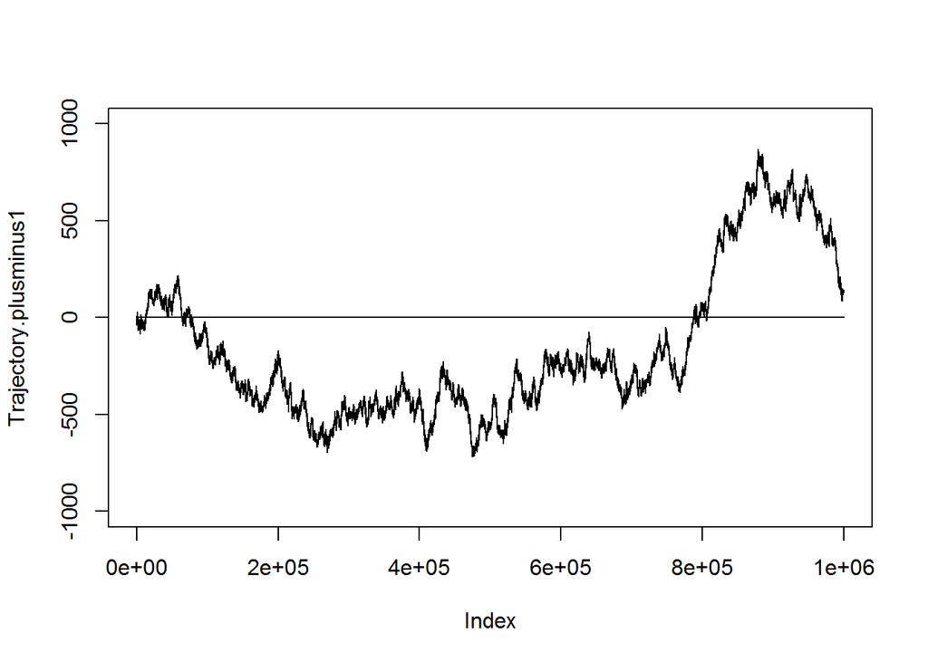

```r
set.seed(23456)
nFlips<-1000000
Flips.plusminus1<-(rbinom(nFlips,1,0.5)-.5)*2
Trajectory.plusminus1<-cumsum(Flips.plusminus1)
plot(Trajectory.plusminus1,ylim=c(-1000,1000),type="l")
lines(c(0,nFlips),c(0,0))
```

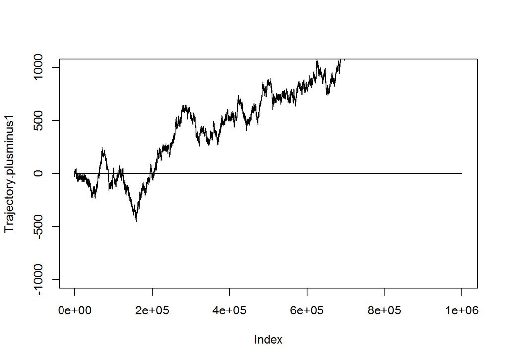

```r
set.seed(34567)
nFlips<-1000000
Flips.plusminus1<-(rbinom(nFlips,1,0.5)-.5)*2
Trajectory.plusminus1<-cumsum(Flips.plusminus1)
plot(Trajectory.plusminus1,ylim=c(-1000,1000),type="l")
lines(c(0,nFlips),c(0,0))
```

### Experiment No. 2:

We will experiment to find the probabilities of the following outcomes:

1. In 500 coin tosses, the difference between the number of Heads and the number of Tails is less than 5 in absolute value.
2. In 500 coin tosses, the difference between the number of Heads and the number of Tails is greater than 25 in absolute value.

Again, by intuition alone, we that the outcome of (1) will be a fairly high probability, because it would mean the trajectories would stay around zero. Similarly, we intuit the outcome of (2) to be much lower. However, as we can see below, that is not the case in reality.

```r
set.seed(12345)
nFlips<-1000000
Flips.plusminus1<-(rbinom(nFlips,1,0.5)-.5)*2
sum(abs(t(apply(matrix(Flips.plusminus1,ncol=500),1,cumsum))[,500])<5)/2000
```

```
## [1] 0.18
```

```r
sum(abs(t(apply(matrix(Flips.plusminus1,ncol=500),1,cumsum))[,500])>=25)/2000
```

```
## [1] 0.2515
```

We also run the same probability experiments with the alternate set.seed numbers.

```r
set.seed(23456)
nFlips<-1000000
Flips.plusminus1<-(rbinom(nFlips,1,0.5)-.5)*2
sum(abs(t(apply(matrix(Flips.plusminus1,ncol=500),1,cumsum))[,500])<5)/2000
```

```
## [1] 0.171
```

```r
sum(abs(t(apply(matrix(Flips.plusminus1,ncol=500),1,cumsum))[,500])>=25)/2000
```

```
## [1] 0.271
```

```r
set.seed(34567)
nFlips<-1000000
Flips.plusminus1<-(rbinom(nFlips,1,0.5)-.5)*2
sum(abs(t(apply(matrix(Flips.plusminus1,ncol=500),1,cumsum))[,500])<5)/2000
```

```
## [1] 0.174
```

```r
sum(abs(t(apply(matrix(Flips.plusminus1,ncol=500),1,cumsum))[,500])>=25)/2000
```

```
## [1] 0.2695
```

From these three iterations of this experiment, we can interpret the results as follows. The probability of the absolute value of the difference between the number of Heads and Tails being less than 5 is lower than it being greater than 25. Thus, we should expect the trajectories to deviate from zero more often than approach/hover around zero.

With respect to how long the trajectory should spend on one side of zero, below or above, before crossing to the other side, we will now have the intuition that it should, in fact, stay on the one side without crossing over to the other. This is due to the probability of a larger difference in Heads and Tails is higher than the probability of a smaller difference. Therefore, there is nothing to suggest that trajectories should stay anywhere close to zero.

### Experiment No. 3:

In a final experiment, we look at how long it takes for a trajectory to cross zero from one side to the other.

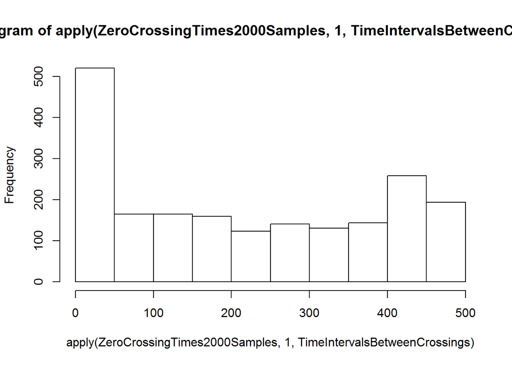

```r
set.seed(12345)
nFlips<-1000000
Flips.plusminus1<-(rbinom(nFlips,1,0.5)-.5)*2
ZeroCrossingTimes2000Samples<-(t(apply((t(apply(matrix(Flips.plusminus1,ncol=500),1,cumsum))==0),1,'*',(1:500))))
TimeIntervalsBetweenCrossings<-function(CrossingTimes){
        return(sum(diff(CrossingTimes[CrossingTimes>0])-1))
}
hist(apply(ZeroCrossingTimes2000Samples,1,TimeIntervalsBetweenCrossings))
```

These results suggest that we will either spend a very short amount of time on one side before crossing or a very long time on one side before crossing. This is similar to our intuition at the end of Experiment No. 2, with one major difference. We can expect the trajectory to cross sides after spending a short amount of time on one side as well as after spending a very long time on one side.

Of note, is that the histogram produced by this code is not perfect in illustrating this effect. This is likely due to the relatively small sample size of 500 flips per instance. If we use a higher number of flips, we may see more clearly the U-shape in the histogram. This behavior that we are observing is known as the Arcsine Law, also known as the Weiner process.

For thoroughness, just as in the previous section, we can use different set.seed numbers to observe slight differences in the random numbers generated for our set of flips. The results are consistent with our initial observations with the original set.seed number.

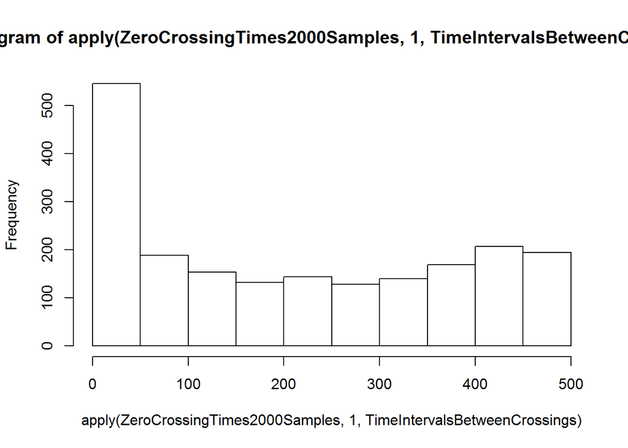

```r
set.seed(23456)
nFlips<-1000000
Flips.plusminus1<-(rbinom(nFlips,1,0.5)-.5)*2
ZeroCrossingTimes2000Samples<-(t(apply((t(apply(matrix(Flips.plusminus1,ncol=500),1,cumsum))==0),1,'*',(1:500))))
TimeIntervalsBetweenCrossings<-function(CrossingTimes){
        return(sum(diff(CrossingTimes[CrossingTimes>0])-1))
}
hist(apply(ZeroCrossingTimes2000Samples,1,TimeIntervalsBetweenCrossings))
```

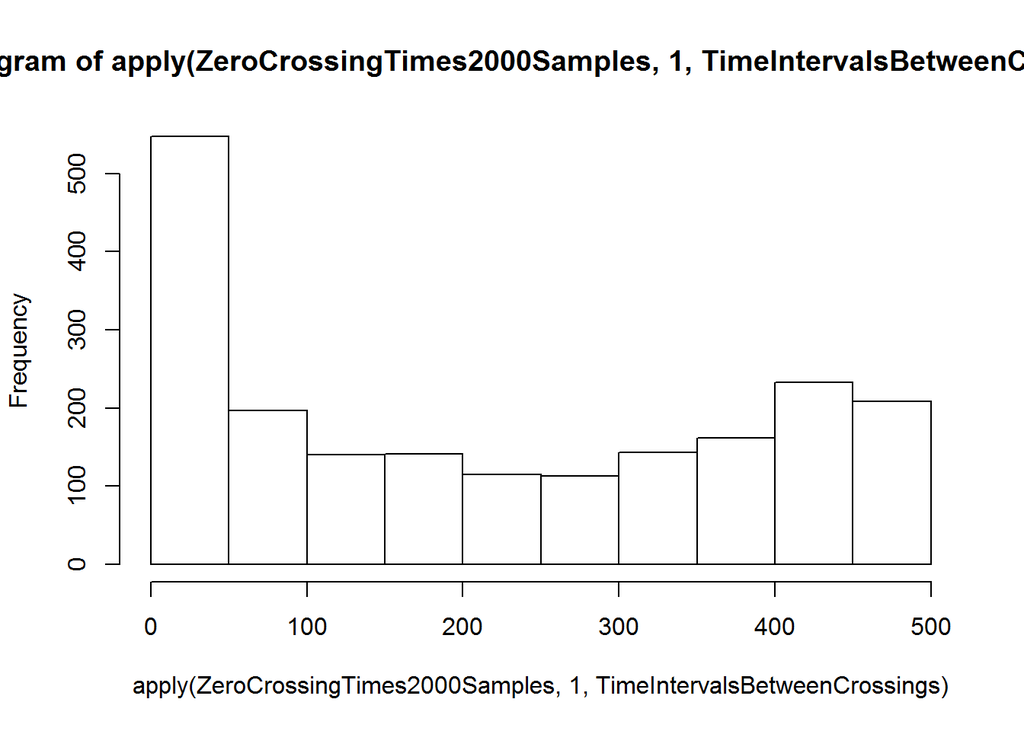

```r
set.seed(34567)
nFlips<-1000000
Flips.plusminus1<-(rbinom(nFlips,1,0.5)-.5)*2
ZeroCrossingTimes2000Samples<-(t(apply((t(apply(matrix(Flips.plusminus1,ncol=500),1,cumsum))==0),1,'*',(1:500))))
TimeIntervalsBetweenCrossings<-function(CrossingTimes){
        return(sum(diff(CrossingTimes[CrossingTimes>0])-1))
}
hist(apply(ZeroCrossingTimes2000Samples,1,TimeIntervalsBetweenCrossings))
```